# Commandes et objets de base, et importation

Mercredi

## Bien se préparer à coder

- Créer un projet dans ce dossier :
  - Bien réfléchir au nom de ce projet
  - Bien réfléchir à l’endroit où ce projet sera situé
- Créer un script
- Savoir où sont les données, et sous quel format
- Savoir ce que l’on veut faire !

## Opérations de base

On peut effectuer toutes les opérations de base en R :

- addition (`+`), soustraction (`-`), multiplication (`*`), division (`/`), exponentiation (`**` ou `^`)…

appliquer les fonctions mathématiques de base :

- logarithme (`log`, `log2`, `log10`), exponentielle (`exp`) sinus (`sin`), cosinus (`cos`), tangente (`tan`)

On peut combiner les opérations et les fonctions, et gérer les priorités avec des parenthèses !

## Un opérateur bien pratique, le `:`

Comment créer une suite d’entier ?

- `c(1, 2, 3, 4)`
- `seq(1, 4, 1`
- `1:4`

L’opérateur `:` est très utilisé en R. Sa syntaxe est la suivante

- \(i\)`:`\(j\) va créer une suite d’entiers de \(i\) à \(j\). Les entiers peuvent être négatifs ou positifs, et on peut peut avoir \(i < j\) ou \(i > j\), ou même \(i = j\).

Attention à bien mettre des **parenthèses** dans le cas d’entiers négatifs!

## Assignation avec `<-`

Comment “sauvegarder” ces objets ?

En utilisant l’**opérateur d’assignation**

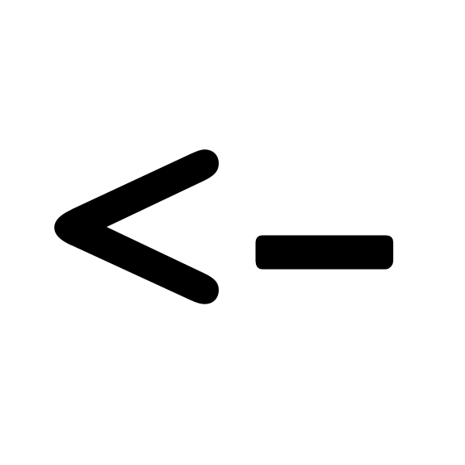

## Utilisation de l’opération d’assignation

- A gauche : l’objet que l’on veut créer
- A droite : sa définition
- Lecture de l’opération : “assigner à cet objet (à gauche) le résultat de cette commande (à droite)”
- Assigner deux fois de suite écrasera la première valeur assignée
- Alternative : `=`
- Exemples : `a <- 1`, `b <- 1:10`, `a <- 2` etc.

## Les noms d’objets

Règles absolues :

- Commence par une lettre ou un point, si le premier caractère est un point, le deuxième ne peut pas être un chiffre,
- Pas d’espace
- Pas de caractères correspondant à des opérations (`+`, `-`, `*`, `/`, `^`, `**`, etc.)
- Les minuscules et les majuscules sont différentes !
- Certains “mots-clefs” sont strictement interdits (`NA`, `TRUE`, `FALSE`, `for`, `if`, `else` etc.)
- MAIS on peut utiliser un nom d’objet qui existe déjà !

Bonnes pratiques :

- Utiliser un nom qui a du sens
- Ne pas utiliser des noms d’objets qui existent déjà et que l’on ne souhaite pas écraser !

## Opérations

On peut appliquer des opérations à ces “vecteurs” !

```r
a <- 1:5
a + 1
```

```
#> [1] 2 3 4 5 6
```

```r
a * 2
```

```
#> [1]  2  4  6  8 10
```

Ces “vecteurs” sont des **objets**.

## Les Objets

## Classes d’objets

| Nom | Appelation officielle | Exemple |
| --- | --- | --- |
| Vecteur | `vector` | `1:10` |
| Facteur | `factor` | `gl(2, 2)` |
| Matrice | `matrix` | `matrix(1:4, 2, 2)` |
| Tableau | `data.frame` | `mtcars` |
| Liste | `list` | `list(a = 1, b = 1:10, c = "Hello!")` |
| Fonction | `function` | `sin`, `exp`, `log` |

Pour connaître la classe d’un objet : `class(objet)`.

## Types de données

| Nom | Appellation officielle | Exemple |
| --- | --- | --- |
| Entier (\(\mathbb Z\)) | `integer` | `1:10`, (ou `1L`) |
| Réel (\(\mathbb R\)) | `double` | `2.3`, `1/3`, etc… |
| Caractères | `character` | `month.name`, `"Bonjour"` |
| Booléen | `logical` | `TRUE` |

## Bouh les quoi ?

> MATH., néol. Qui est relatif aux théories du logicien et mathématicien anglais George Boole.

> – *Trésor de la Langue Française informatisé*
- `TRUE` (ou bien `T`) et `FALSE` (ou bien `F`)
- Résultat d’une comparaison : `==`, `!=`, `<`, `>`, `<=`, `>=`
- Opérations logiques : `!`, `&`, `|`, `xor`

## Exercice

1. Effectuez les opérations suivantes :
- `1 == 2`
- `!(5 > -6)`
- `(1 <= 10) | (1 > 0)`
1. Prédisez le résultat de la commande suivante : `log(1) != 0`

## “Classification” des objets

Les objets qui ne contiennent qu’un seul type de données : vecteurs et matrices.

Les objets pouvant contenir des données mixtes : tableaux et listes.

La flexibilité a un coût : on ne peut plus faire certaines opérations !

Les objets ayant des “dimensions” : vecteurs, tableaux et matrices

Les objets pour qui cela ne signifie rien ou presque : listes et fonctions

## Les tableaux

```r
data("fruits", package = "intro2r")
fruits
```

```
#>                                   nom   groupe Energie  Eau
#> Abricot                       Abricot     crus     194 87.1
#> Abricot.1                     Abricot     secs    1010 24.7
#> Ananas                         Ananas exotique     304 81.3
#> Banane                         Banane exotique     383 75.8
#> Canneberge                 Canneberge     secs    1410 14.6
#> Cerise                         Cerise     crus     235 85.7
#> Citron                         Citron     crus     118 91.3
#> Clementine                 Clementine     crus     200 87.0
#> CompoteMultiFruits CompoteMultiFruits  compote     279 82.9
#> CompotePomme             CompotePomme  compote     432 72.9
#> Figue                           Figue     crus     293 80.2
#> Fraise                         Fraise     crus     162 90.3
#> Framboise                   Framboise     crus     206 86.8
#> FruitCru                     FruitCru     crus     251 84.5
#> Grenade                       Grenade     crus     340 79.4
#> Groseille                   Groseille     crus     289 82.1
#> Kaki                             Kaki exotique     290 81.8
#> Kiwi                             Kiwi exotique     255 83.5
#> Lime                             Lime exotique     170 86.3
#> Litchi                         Litchi exotique     344 80.5
#> Mangue                         Mangue exotique     376 77.1
#> Maracuja                     Maracuja exotique     425 73.6
#> Melange                       Melange     secs    1640 11.7
#> Melon                           Melon     crus     265 84.2
#> Mirabelle                   Mirabelle     crus     325 78.1
#> Mure                             Mure     crus     198 86.1
#> Myrtille                     Myrtille     crus     244 84.2
#> NectarineBlanche     NectarineBlanche     crus     220 86.5
#> NectarineJaune         NectarineJaune     crus     218 86.6
#> Orange                         Orange     crus     192 87.3
#> Pamplemousse             Pamplemousse     crus     169 89.3
#> Papaye                         Papaye exotique     178 88.8
#> Papaye.1                       Papaye exotique     169 88.6
#> Pasteque                     Pasteque     crus     165 91.0
#> PecheBlanche             PecheBlanche     crus     199 87.6
#> PecheBlanche.1           PecheBlanche     crus     195 87.6
#> PecheJaune                 PecheJaune     crus     196 87.8
#> PoireConference       PoireConference     crus     223 85.3
#> PoireWilliams           PoireWilliams     crus     228 84.7
```

[output cut: 153 more lines]

```
#> PecheJaune         0.090       130.00      0.50      3.43
#> PoireConference    0.070        19.30      0.04      1.39
#> PoireWilliams      0.090         2.50      0.04      2.57
#> PommeGolden        0.070        56.00      0.04      0.25
#> PommeChantecler    0.050        54.60      0.04      2.85
#> PommeGala          0.050        11.60      0.04      1.33
#> PommeGrannySmith   0.050        11.60      0.04      2.31
#> PommePinklady      0.050        32.30      0.04      2.13
#> Prune              0.120       430.00      1.20      4.16
#> Pruneau            0.280        14.90      0.41      0.25
#> PureeDeFruits      0.050        31.00      0.40     16.70
#> Raisin             0.240         2.50      1.67      0.25
#> RaisinBlanc        0.050         7.54      0.31      1.07
#> RaisinChasselas    0.070        27.40      0.35      4.14
#> RaisinNoirMuscat   0.060        67.70      0.99      3.11
```

## Les données “de R”

- Utiliser la commande `data()` pour avoir une liste (presque ?) exhaustive.
- Bonne pratique : pour charger un jeu de données, utiliser la commande complète `data("nom_des_data", package = "nom_du_package")`
- Mais ces alternatives fonctionnent également :
  - `data(mtcars)`
  - `DNase`
  - `library(ggplot2) ; data(diamonds)`

## Utilisation des guillemets

- Obligation : quand l’argument doit être une chaîne de caractères
- Oubli : `library`, `require`, `data`
- Guillemets simples : fonctionnent comme les guillemets doubles. Ex.: `"bonjour"` est équivalent à `'bonjour'`.
- Le “backtick” ou “backquote” : “`”

## Explorer les données `fruits`

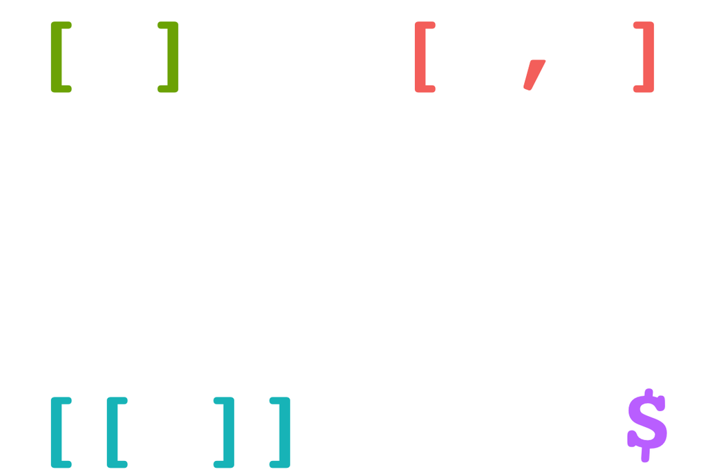

## Sur quels objets les utiliser ?

| Opérateur | Vecteurs | Matrices | Tableaux | Listes |
| --- | --- | --- | --- | --- |
| `[ ]` | x |  | x | x |
| `[ , ]` |  | x | x |  |
| `[[ ]]` |  |  | x | x |
| `$` |  |  | x | x |

## L’opérateur de sélection classique : `[ , ]`

- Pour sélectionner la première ligne : `fruits[1, ]`
- Pour sélectionner la deuxième colonne : `fruits[, 2]`
- Pour enlever la troisième ligne : `fruits[-3, ]`
- Pour enlever la quatrième colonne : `fruits[, -4]`

## Sélectionner plusieurs lignes / colonnes

- Pour sélectionner les lignes 1 et 3 : `fruits[c(1, 3), ]`
- Pour sélectionner les colonnes 2 et 4 : `fruits[, c(2, 4)]`
- Pour enlever les lignes 5 et 7 : `fruits[-c(5, 7), ]`
- Pour enlever les colonnes 6 et 8 : `fruits[, -c(6, 8)]`

## De l’utilité des deux points

Pour sélectionner une plage entière de lignes ou de colonnes adjacentes :

- Pour sélectionner les lignes 11 à 17 : `fruits[11:17, ]`
- Pour sélectionner les colonnes 3 à 5 : `fruits[, 3:5]`
- Pour enlever les trois premiers fruits : `fruits[-(1:3), ]`
- Pour enlever les cinq premières variables : `fruits[, -(1:5)]`

## Exercice

Que se passe-t-il quand on oublie les parenthèses dans la commande `fruits[-(1:3), ]` ? Commentez !

Faites de même avec le jeu de données `mtcars`.

## Pour extraire une seule colonne : le `$`

La syntaxe `donnees$cible` permet de sélectionner la colonne `cible` du tableau `donnees`.

- Par exemple : `fruits$Eau`
- Autre exemple : `fruits$groupe`

## Exercice

Extrayez la colonne de la teneur en sucres de la table des fruits… de deux façons différentes !

Créez un objet contenant la teneur en sucres : quelle est la classe de cet objet ?

## Les vecteurs…

- … sont “unidimensionnels”
- … ont une classe qui est égale au type de données qu’ils contiennent (R !!!)
- … sont indexés avec des crochets simples

Exemples :

- `i <- 1:10`
- `eau <- fruits$Eau`
- `eau[i]`

## Exercice

Créez un vecteur `groupe` contenant les groupes de fruits. Donnez deux façons différentes d’extraire les dix premières valeurs de ce vecteur.

## Extraction avec des Booléens

Comment extraire les fruits … * dont la teneur en eau est supérieure à 60 ? * exotiques ? * secs contenant moins de 40g/100g de sucres ?

Réponse : en utilisant des vecteurs booléens

1. Créer le vecteur de booléens `fruits$Eau >= 60`
2. Utiliser le résultat dans les crochets carrés `fruits[fruits$Eau >= 60, ]`

Ne pas oublier la virgule !

## Le principe

Pour un vecteur `v` :

- `v[bool]` extrait les valeurs de `v` pour lesquelles `bool` est vrai (`TRUE`). Contrainte : `v` et `bool` doivent contenir **le même nombre d’éléments**.

Pour un tableau `tab` :

- `tab[brow, ]` pour extraire les lignes
- `tab[, bcol]`
- Contrainte 1 : `brow` doit avoir autant d’éléments que `tab` de lignes
- Contrainte 2 : `bcol` doit avoir autant d’éléments que `tab` de colonnes

## Attention

Vous verrez souvent des opérations logiques à l’intérieur des crochets carrés : cela permet d’aller plus vite !

Par exemple, en deux étapes :

1. `bool <- fruits$groupe == "secs" & fruits$Sucres < 40`
2. `fruits[bool, ]`

Devient, en une étape :

- `fruits[fruits$groupe == "secs" & fruits$Sucres < 40, ]`

## Attention bis

On peut combiner deux méthodes d’extraction de données pour un tableau : une sur les lignes et une sur les colonnes !

Par exemple : `tab[brow, icol]`, où `brow` est un vecteur de booléens et `icol` un vecteur d’indices.

## Exercice

Construisez la sous-table contenant la teneur en protéines, en glucides et en lipides des fruits secs.

## Les objets nommés

En R, on peut donner des “noms”…

- aux éléments d’un vecteur,
- aux lignes d’un tableau ou d’une matrice,
- aux colonnes d’un tableau ou d’une matrice,
- aux éléments d’une liste

Pourquoi ? Pour pouvoir disposer d’une nouvelle méthode d’extraction de données !

## Pour un tableau

On utilise :

- `rownames(tab)` pour connaître le nom des lignes
- `colnames(tab)` pour connaître le nom des colonnes

Et, en bonus, on peut :

- changer les noms des lignes `rownames(tab) <- new1`
- changer les noms des colonnes `colnames(tab) <- new2`

Et, en super bonus, on peut :

- modifier quelques noms de lignes `rownames(tab)[sel1] <- new1`
- modifier quelques noms de colonnes `rownames(tab)[sel1] <- new2`

## Modifier un objet ou son contenu

La syntaxe `obj[i] <- newvalue` (et ses variations) peut être utilisée pour tous les types d’objets indiçables. Mais il faut l’utiliser avec prudence !

Exemple : `fruits$Energie[1:10] <- 0`

Que s’est-il passé ? **Au secours !!!!**

Pour revenir en arrière : `data("fruits", package = "intro2r")`

## Extraction avec des noms

Exemple :

- Pour extraire l’énergie : `fruits[, "Energie"]`,
- Pour extraire le groupe : `fruits[, "groupe"]`,
- Pour extraire l’énergie et le groupe : `fruits[, c("Energie", "groupe")]`,
- Pour enlever le groupe : `fruits[, -"groupe"]` ?

## Bilan

| Mode d’extraction | Exemples |
| --- | --- |
| Indices | `fruits[, 2]` |
| Booléens | `fruits[fruits$nom == "Abricot", ]` |
| Noms | `fruits$nom` ou `fruits[,"nom"]` |

## Exercice

Lister le maximum de façons possibles d’extraire du tableau `fruits` les fruits crus sucrés riches en Vitamine C !

## Construire ses propres objets

## Vecteurs et facteurs

- La fonction `c()` permet de combiner des valeurs dans un vecteur. Attention, tout doit être du même “type” !
- La fonction `seq` permet de créer des suites.
- La fonction `rep` permet de créer des vecteurs en répétant des valeurs. Ex: `rep(c("a", "b"), c(3, 4))`

Les facteurs sont une particularité de R !

- On les crée avec la fonction `factor` ou `as.factor`
- Par exemple : `factor(fruits$groupe)`

## Ajouter des noms

Directement à la création de l’objet. Ex: `x <- c(a = 1, b = 2)`, `d <- data.frame(a = 1:26, b = letters)`

Ou bien après la création de l’objet :

- `names(obj) <- lesNoms` pour un vecteur
- `rownames(obj) <- lesLignes` pour les lignes d’un tableau ou d’une matrice,
- `colnames(obj) <- lesColonnes` pour les colonnes d’un tableau ou d’une matrice.

## Exercice

Créez un facteur à partir des groupes de fruits, puis testez la commande suivante :

```
factor(fruits$groupe, levels = c("secs", "compote", "crus", "exotique"))
```

Que se passe-t-il ? Sauvez le résultat dans un objet et faites un diagramme en bâton avec ! Commentez !

## Estimation ponctuelle

## Définition

Il s’agit d’estimer un caractéristique statistique d’un ensemble de données avec une seule valeur.

| Paramètre | Grandeur statistique | Commande |
| --- | --- | --- |
| Position | Moyenne | `mean` |
| Position | Médiane | `median` |
| Position | Minimum | `min` |
| Position | Maximum | `max` |
| Dispersion | Variance | `var` |
| Dispersion | Ecart-type | `sd` |
| Dispersion | Intervalle inter-quartiles | `IQR` |
| Lien | Covariance | `cov` |
| Lien | Corrélation | `cor` |

## Rappel : la covariance

Permet de mesurer le degré de co-variation de deux variables :

\[ \operatorname{cov}(x, y)=\frac{1}{n-1} \sum_{i=1}^{n}\left(x_{i}-m_{x}\right)\left(y_{i}-m_{y}\right) \]

## Rappel : corrélation de Pearson

C’est une covariance normalisée entre -1 et 1 !

\[ \operatorname{cor}(x, y)=\frac{\operatorname{cov}(x, y)}{\sqrt{\operatorname{var}(x)} \sqrt{\operatorname{var}(y)}} \]

## Rappel : corrélation de Spearman

C’est la corrélation (de Pearson) calculée sur les rangs !

\[ \rho = \operatorname{cor}(r_x, r_y), \] avec \(r_x\) le vecteur des rangs de \(x\) (`rank(x)`), et \(r_y\) le vecteur des rangs de \(y\) (`rank(y)`).

## Rappel (?) : corrélation de Kendall

- Paire concordante : \(\left(x_{i}<x_{j} \text { et } y_{i}<y_{j}\right)\) OU \(\left(x_{i}>x_{j} \text { et } y_{i}>y_{j}\right)\)
- Paire discordante : \(\left(x_{i}<x_{j} \text { et } y_{i}>y_{j}\right)\) OU \(\left(x_{i}>x_{j} \text { et } y_{i}<y_{j}\right)\)

\[ \tau = \displaystyle \frac{n_C - n_D}{n_0}, \] avec \(n_C\) le nombre de paires concordantes, \(n_D\) le nombre de paires discordantes et \(n_0\) le nombre total de paires de points.

## Exercice

Calculez

- la médiane de la teneur en sucres
- la moyenne de la teneur en eau
- l’écart-type de la teneur en eau

Appliquez la fonction `summary` aux données `fruits`.

- Calculez la corrélation de Pearson entre la teneur en eau et la teneur en sucres,
- Calculez la corrélation de Spearman

## Les fonctions astucieuses

- `summary` pour obtenir des statistiques
- `str` pour la structure des données
- `table` pour faire des tables de comptage
- `seq_along` pour créer un vecteur d’indices de même longueur qu’un vecteur donné

## D’autres fonctions très utilies

- `sum` pour calculer la somme de nombres
- `sort`, `order` et `rank` pour ordonner, et calculer les rangs
- `rowSums` et `colSums` pour calculer les sommes des lignes et colonnes d’une table,
- `rowMeans` et `colMeans` pour calculer les moyennes des lignes et colonnes d’une table,

## Les graphes de base

- `barplot` : diagrammes en bâtons
- `hist` : histogrammes
- `plot` : nuages de points

## La fonction `barplot`

Permet de réaliser des diagrammes en bâtons :

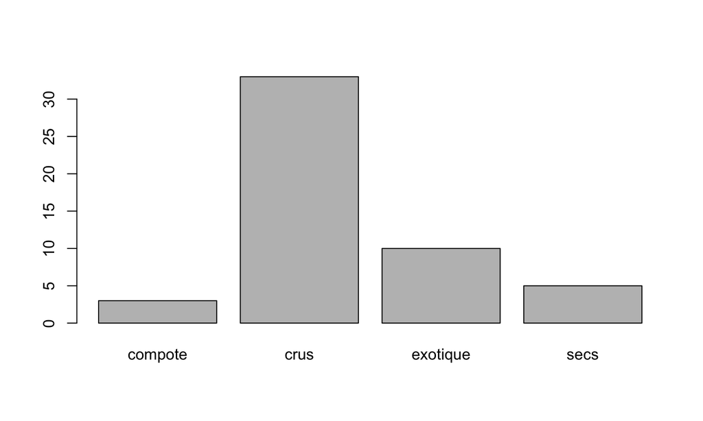

```r
barplot(table(fruits$groupe))
```

## La fonction `hist`

Permet de réaliser des histogrammes :

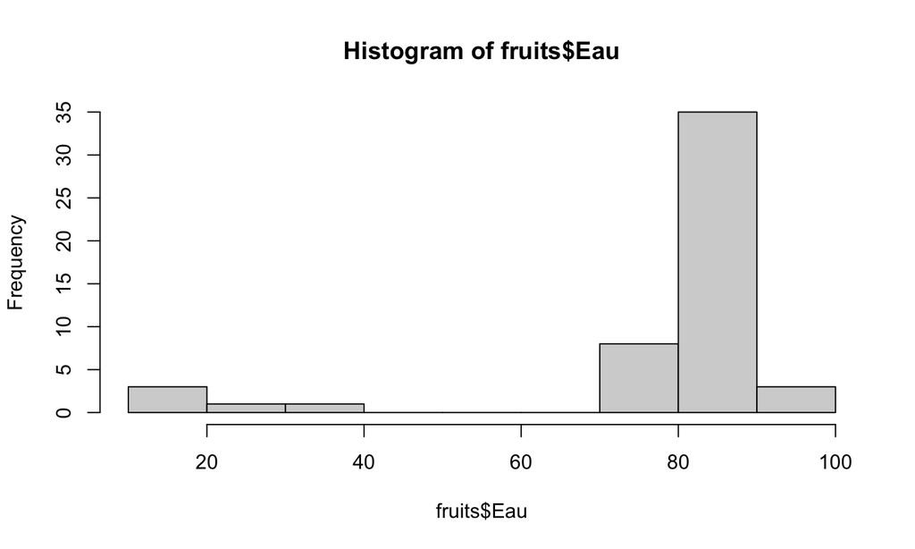

```r
hist(fruits$Eau)
```

## La fonction `plot`

Permet de tracer des nuages de points :

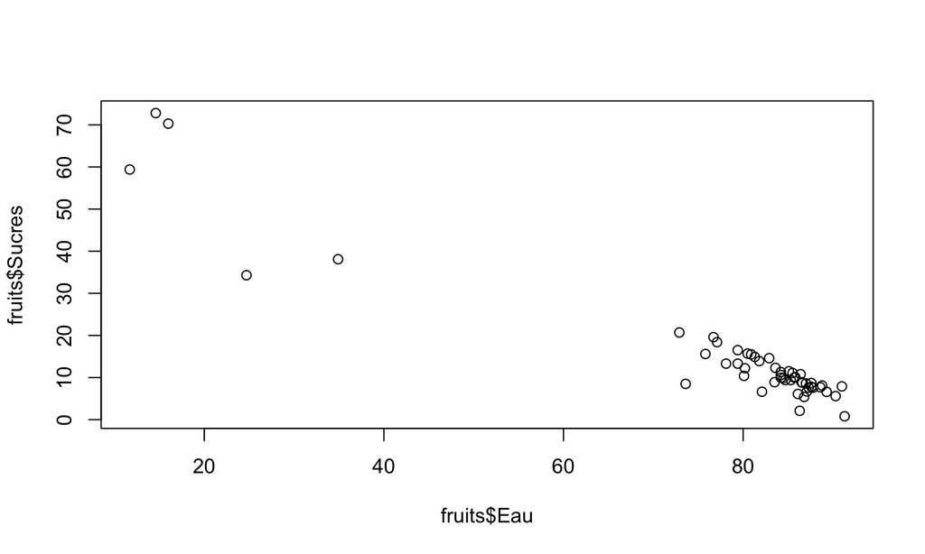

```r
plot(fruits$Eau, fruits$Sucres)
```

## Exercice

Faire un histogramme de la teneur en Vitamine C des fruits crus.

## Import de données

## Rappels sur les fonctions

Lire des fichiers tabulés : `read.table`, `read.csv`, `read.csv2`, `read.delim`, `read.delim2`.

Lire des fichiers Excel : `openxlsx::read.xlsx`(, `readxl::read_excel`)

Mais on peut utiliser aussi le menu “Import Dataset” de Rstudio !

## Exercice

1. Téléchargez les données Nutriwi (https://vguillemot.github.io/intro2r/inst/extdata/nutrimenu.csv).
2. Placez ces données dans votre **dossier de travail**
3. Importez ces données dans votre **environnement**
4. Explorez rapidement les données Nutriwi avec les fonctions `class`, `dim`, `summary` etc.